# Midterm

### Step5: Check the missing values in both data set.

```r
sum(is.na(sdi1))
```

```
## [1] 0
```

```r
sum(is.na(totcases1))
```

```
## [1] 0
```

### Step6: Draw the barchart of total US confirmed cases on Sep/28/2020.

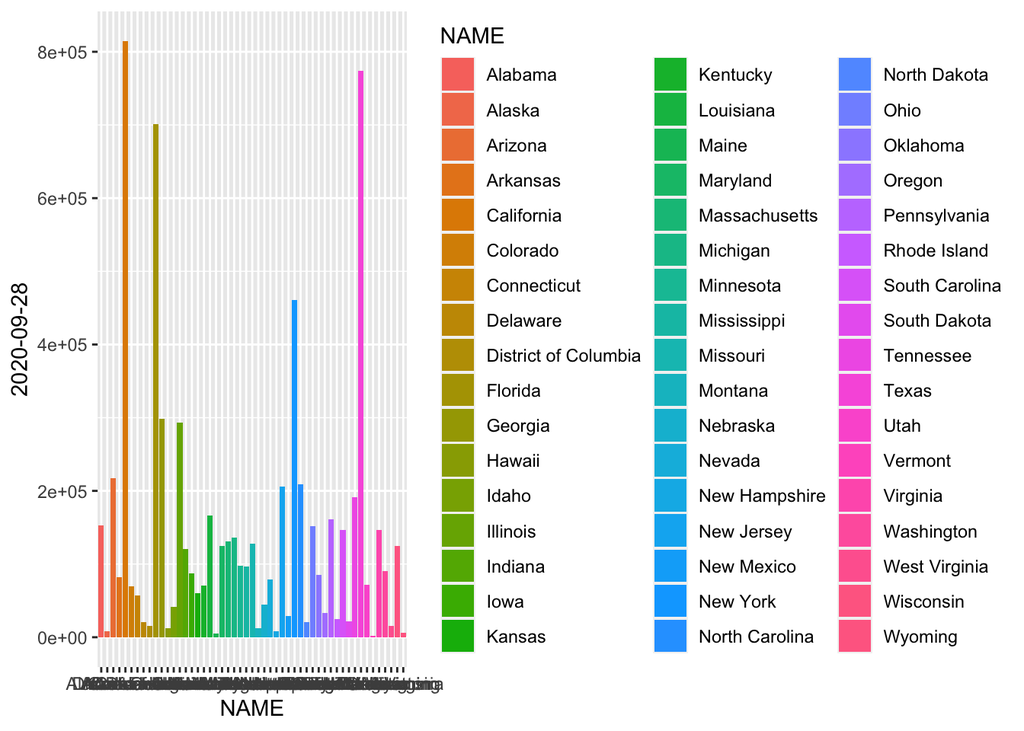

```r
library(ggplot2)
tot0928<-totcases1[ ,c(2,254)]
ggplot(tot0928,aes(x=NAME, y=`2020-09-28`, fill=NAME))+geom_bar(stat = 'identity')
```

### Step7: Find which states have the total confirmed cases on Sep/28/2020 which are over 200,000.

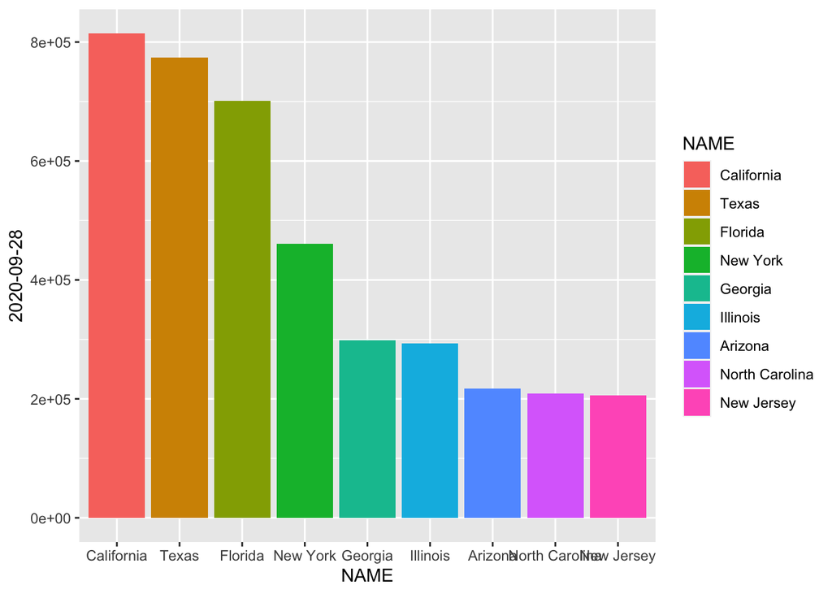

```r
tot0928a<-tot0928[`2020-09-28`>200000,]
tot0928a$NAME<-reorder(tot0928a$NAME, -tot0928a$`2020-09-28`)
ggplot(tot0928a,aes(x=NAME, y=`2020-09-28`, fill=NAME))+geom_bar(stat = 'identity')
```

### Step8: Compare the social distance index with the total confirmed cases in the states which are over 200,000.

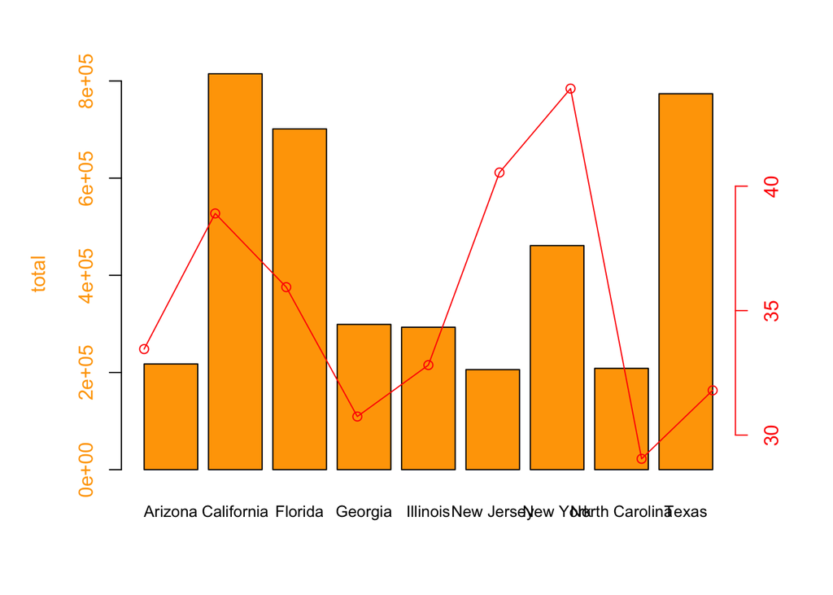

```r
sdistate = sdi1[c(3,5,10,11,14,31,33,34,44),2]
sdistate1 = sdi1[c(3,5,10,11,14,31,33,34,44),3:254]
sdistatez = sdistate
meandis = apply(sdistate1,1,mean)
sdistatez$name = sdistate
sdistatez$meandis = meandis
total = tot0928a$`2020-09-28`
sdistatez$total = total

par(mar = c(5, 5, 3, 4)+0.1)
bar = barplot(sdistatez$total,ylab="total",
col="orange",col.axis="orange",col.lab="orange")
mtext(sdistatez$name,side=1,line=1,at=bar,cex=0.8,col="black")
par(new=T)
plot(bar,sdistatez$meandis,axes=F,xlab="",ylab=" ",col="red",type="o")
axis(4,col="red",col.ticks="red",col.axis="red")
```

### Step9: Plot the mean values of social distance index of the 9 states on the map.

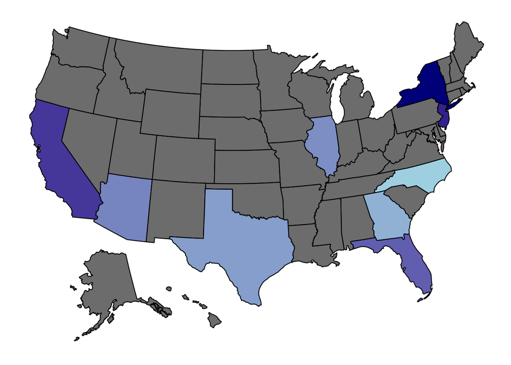

```r
library(usmap)
sdistatem = as.data.frame(sdistatez)
names(sdistatem)[2] <- "state"
plot_usmap('states', data =sdistatem, values ='meandis')+
scale_fill_continuous(low = "light blue", high = "dark blue", guide = FALSE)
```

- The states in grey color are those who have total confirmed cases lower than 200,000, which I did not calculate the mean values.
- The states in blue color are those who have total confirmed cases over than 200,000, which I have calculated the mean values before. The dark blue indicates the higher mean of social distance index, the light blue indicates the lower mean of social distance index.

### Step10: Find whether the variable of total confirmed cases and the variable of mean social distance are related.

```r
meandisz = apply(sdi1[,3:51],1,mean)
totalz = tot0928$`2020-09-28`
cor(meandisz,totalz)
```

```
## [1] -0.09747817
```

- The correlation coefficient is -0.097 which is very close to 0, so we can find that these two variables are not related.